# UFO Data Analysis

Carrie Wright

2025-06-24

We previously saw that population might be impacting the number of sightings. We will now get some data to check that. A package called `tidycensus` can be very helpful for getting this kind of data.

## Load our tools and data

First we need to load our tools - including the tidyverse and also read in the data, which we can do directly in R.

```r
library(tidyverse)
library(tidycensus)
library(DT)
library(readxl)
UFO <- read_rds("UFO_clean.rds")
US_2014 <- read_rds("UFO_2014.rds")
lower_states <- read_rds("lower_states.rds")
state_names <- tibble(state = tolower(state.name), abrev = tolower(state.abb))
```

First let’s get some data about population.

Found some here: https://www.census.gov/data/tables/time-series/demo/popest/intercensal-2010-2020-state.html

https://www2.census.gov/programs-surveys/popest/tables/2010-2020/intercensal/national/nst-est2020int-pop.xlsx

```r
#download.file("https://www2.census.gov/programs-surveys/popest/tables/2010-2020/intercensal/national/nst-est2020int-pop.xlsx", destfile = "pop.xlsx")
pop_data <- read_excel("pop.xlsx", skip = 3)
```

```r
library(maps)
pop_data <-rename(pop_data, "Location" = `...1`)
pop_data <-pop_data %>% filter(str_detect(Location, "^\\."))
pop_data <- pop_data %>% mutate(Location = str_remove(Location, pattern = "."))
pop_data <- pop_data %>% mutate(Location = tolower(Location))

pop_data <-full_join(pop_data, state_names, by = c("Location"  = "state"))

pop_data_2014 <- select(pop_data, Location, `2014`, abrev)

pop_data_2014  <- pop_data_2014 %>% rename("population" = `2014`)
US_2014_summ<-US_2014 %>% group_by(state) %>% summarize( frequency = n())
US_2014_pop <-left_join(US_2014_summ, pop_data_2014, by = c("state" = "abrev"))

US_2014_pop <-US_2014_pop %>% mutate(sightings_per_100000 = frequency/population*100000)
head(US_2014_pop)
```

```
## # A tibble: 6 × 5
##   state frequency Location   population sightings_per_100000
##   <chr>     <int> <chr>           <dbl>                <dbl>
## 1 ak           24 alaska         737634                3.25
## 2 al           51 alabama       4887757                1.04
## 3 ar           10 arkansas      2961050                0.338
## 4 az          116 arizona       6629890                1.75
## 5 ca          307 california   38637421                0.795
## 6 co           44 colorado      5342212                0.824
```

Let’s see if frequency of sightings and population are correlated.

```r
cor.test(US_2014_pop$frequency, US_2014_pop$population)
```

```
##
##  Pearson's product-moment correlation
##
## data:  US_2014_pop$frequency and US_2014_pop$population
## t = 9.3007, df = 47, p-value = 3.15e-12
## alternative hypothesis: true correlation is not equal to 0
## 95 percent confidence interval:
##  0.6769934 0.8856764
## sample estimates:
##       cor
## 0.8049526
```

**Question**: How do you interpret this analysis?

**Possible Answer**

We have a fairly strong and positive correlation of 0.8.

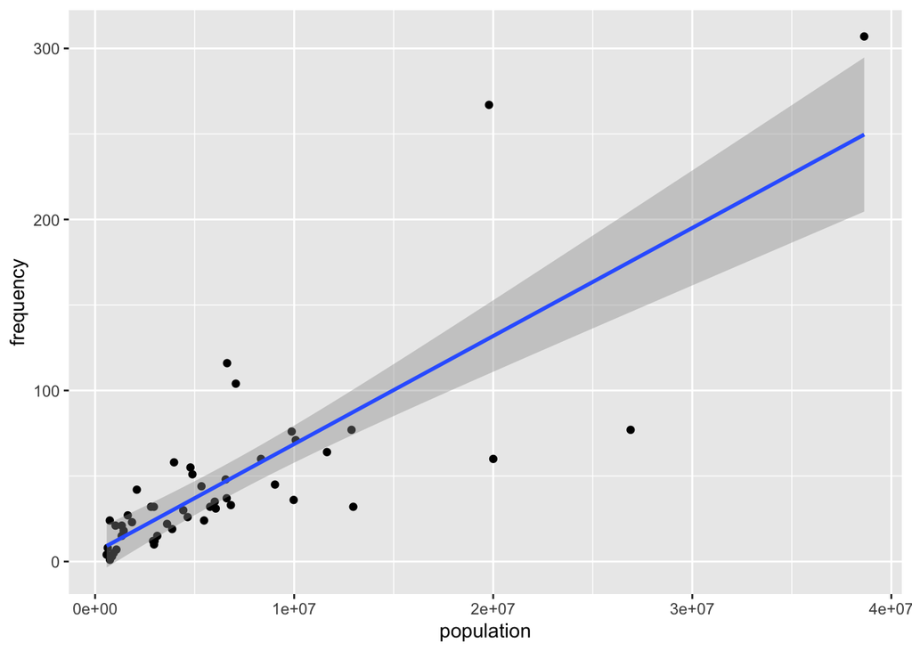

```r
ggplot(US_2014_pop, aes(population, frequency)) + geom_point()+ geom_smooth(method = "lm")
```

The graph confirms what we saw from our correlation test.

Let’s take a look at our plot now”

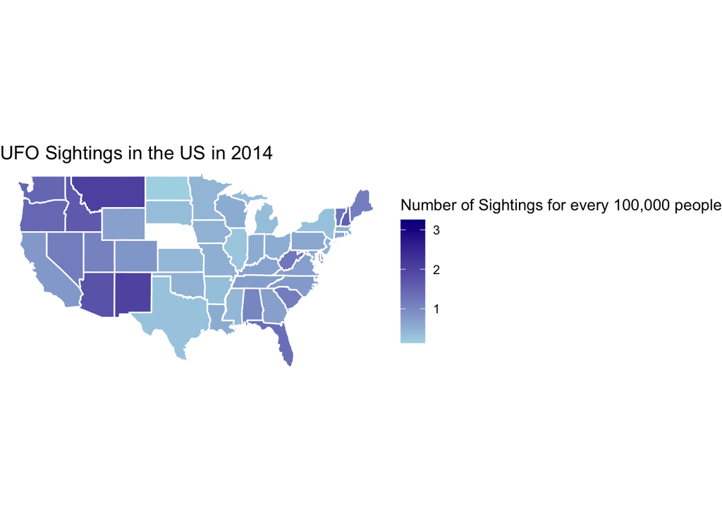

```r
us_map <- map_data("state")
us_map <- us_map %>%
  full_join(US_2014_pop, by = c("region" = "Location"))

ggplot(data = us_map, aes(x = long, y = lat, group = group, fill = sightings_per_100000)) +
  geom_polygon(color = "white") +
  coord_fixed(1.3) +
  theme_minimal() +
  labs(title = "UFO Sightings in the US in 2014", fill = "Number of Sightings for every 100,000 people") +
  scale_fill_gradient(low = "lightblue", high = "darkblue", na.value = "white") + theme_void()
```

Here are the top 10 states in 2014:

```r
US_2014_pop %>% arrange(desc(sightings_per_100000)) %>% head(n= 10)
```

```
## # A tibble: 10 × 5
##    state frequency Location      population sightings_per_100000
##    <chr>     <int> <chr>              <dbl>                <dbl>
##  1 ak           24 alaska            737634                 3.25
##  2 mt           21 montana          1025126                 2.05
##  3 nm           42 new mexico       2095081                 2.00
##  4 az          116 arizona          6629890                 1.75
##  5 id           27 idaho            1641124                 1.65
##  6 nh           21 new hampshire    1339344                 1.57
##  7 wa          104 washington       7068971                 1.47
##  8 or           58 oregon           3965375                 1.46
##  9 fl          267 florida         19790139                 1.35
## 10 vt            8 vermont           633872                 1.26
```

What about from 2010-2014?

```r
UFO_us <-UFO %>% filter(country_new == "US")
UFO_us <-UFO_us %>% separate(datetime, into = c("date", "time"), sep = " ")
UFO_us <-UFO_us %>% mutate(date = mdy(date)) %>% mutate(year = year(date))%>% glimpse()
```

```
## Rows: 77,210
## Columns: 14
## $ date                   <date> 1949-10-10, 1949-10-10, 1956-10-10, 1960-10-10…
## $ time                   <chr> "20:30", "21:00", "21:00", "20:00", "19:00", "2…
## $ city                   <chr> "san marcos", "lackland afb", "edna", "kaneohe"…
## $ state                  <chr> "tx", "tx", "tx", "hi", "tn", "ct", "al", "fl",…
## $ country_new            <chr> "US", "US", "US", "US", "US", "US", "US", "US",…
## $ country                <chr> "us", NA, "us", "us", "us", "us", "us", "us", "…
## $ shape                  <chr> "cylinder", "light", "circle", "light", "sphere…
## $ `duration (seconds)`   <dbl> 2700, 7200, 20, 900, 300, 1200, 180, 120, 300, …
## $ `duration (hours/min)` <chr> "45 minutes", "1-2 hrs", "1/2 hour", "15 minute…
## $ comments               <chr> "This event took place in early fall around 194…
## $ `date posted`          <chr> "4/27/2004", "12/16/2005", "1/17/2004", "1/22/2…
## $ latitude               <chr> "29.8830556", "29.38421", "28.9783333", "21.418…
## $ longitude              <dbl> -97.94111, -98.58108, -96.64583, -157.80361, -8…
## $ year                   <dbl> 1949, 1949, 1956, 1960, 1961, 1965, 1966, 1966,…
```

```r
UFO_us<- UFO_us %>% filter(year %in%  c(2010,2011,2012,2013,2014))

UFO_us_summ <-UFO_us %>%group_by(year, state) %>% summarize(frequency = n())

pop_data_long <-pivot_longer(pop_data, cols = -c(abrev, Location), names_to = "year", values_to = "population")
pop_data_long  <- pop_data_long  %>% mutate(year = as.numeric(year))

UFO_US_pop <-left_join(UFO_us_summ, pop_data_long, by =  c("state" = "abrev", "year" = "year" ))
UFO_US_pop <-UFO_US_pop %>% mutate(sightings_per_100000 = frequency/population*100000)
```

**Question**: How has the plot changed?

**Answer**

We can see that california is not as different compared to the other states as before. We can also see that New Mexico is darker. This indicates that for California, a higher population was leading to leading to more sightings, on the flip side for New Mexico, the low population of the state was leading to less sightings. However when we accounted for population we could see that the picture looked much different for these states.

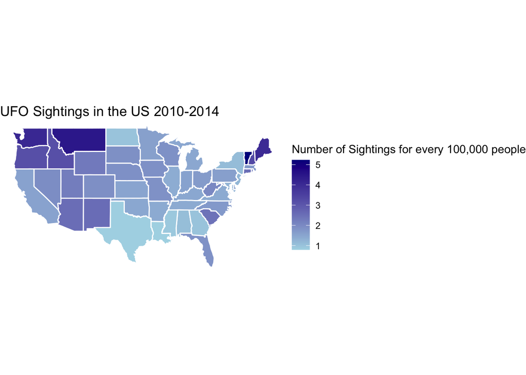

```r
US_sum <-UFO_US_pop %>% group_by(Location) %>% summarize(mean_sightings = mean(sightings_per_100000))
us_map <- map_data("state")
us_map <-full_join(us_map, US_sum, by = c("region" = "Location"))

ggplot(data = us_map, aes(x = long, y = lat, group = group, fill = mean_sightings)) +
  geom_polygon(color = "white") +
  coord_fixed(1.3) +
  theme_minimal() +
  labs(title = "UFO Sightings in the US 2010-2014", fill = "Number of Sightings for every 100,000 people") +
  scale_fill_gradient(low = "lightblue", high = "darkblue", na.value = "white") + theme_void()
```

Here are the top 10 states overall:

```r
US_sum %>% arrange(desc(mean_sightings)) %>% head(n= 10)
```

```
## # A tibble: 10 × 2
##    Location      mean_sightings
##    <chr>                  <dbl>
##  1 vermont                 5.23
##  2 montana                 4.45
##  3 alaska                  4.29
##  4 washington              4.08
##  5 maine                   4.00
##  6 new hampshire           3.31
##  7 oregon                  3.16
##  8 idaho                   3.16
##  9 new mexico              2.56
## 10 arizona                 2.55
```